# Effect of selective regime on gene expression in B. plicatilis

J. Ignacio Lucas Lledó

# Model 2

```r
qlf2  <- glmQLFTest(fit2, coef=2)
topTags(qlf2)
```

```
## Coefficient:  regimerandom
##                  logFC     logCPM         F       PValue         FDR
## XLOC_027655  0.9251752  8.9286486 113.13819 1.099287e-07 0.001675758
## XLOC_008190 -2.5310748  2.9391708  96.34454 2.747724e-07 0.001675758
## XLOC_026645 -0.7191677  6.5800094  96.12429 2.783511e-07 0.001675758
## XLOC_028689 -1.8862052  0.5803148  70.32767 1.576704e-06 0.001675758
## XLOC_038903 -2.1291226  1.2166006  68.44789 1.826486e-06 0.001675758
## XLOC_005911  0.9637810  4.3170079  68.29836 1.848251e-06 0.001675758
## XLOC_050984 -0.8177441  6.7958221  67.75819 1.929419e-06 0.001675758
## XLOC_033378 -3.3122199 -0.8898586  66.75531 2.091317e-06 0.001675758
## XLOC_002252 -1.0845811  4.2867859  63.20611 2.805221e-06 0.001675758
## XLOC_032135 -0.8194344  7.5600216  62.73497 2.919794e-06 0.001675758
```

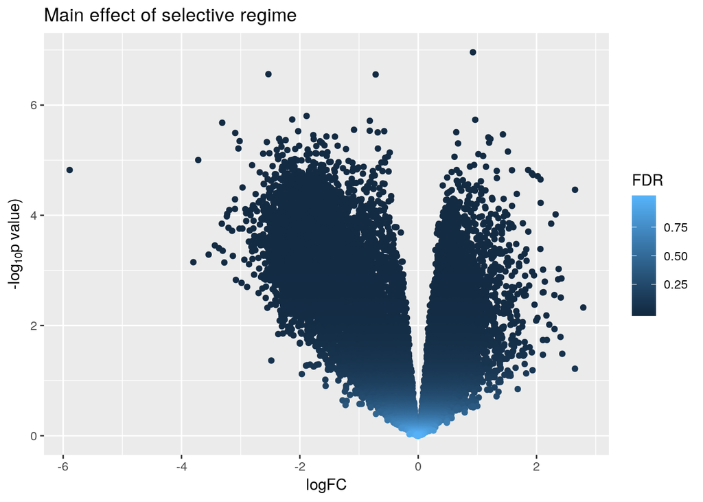

```r
z1 <- topTags(qlf2, n=NumOfTags)$table
z1$logPValue <- -log10(z1$PValue)
ggplot(data=z1, mapping=aes(x=logFC, y=logPValue, color=FDR)) +
   geom_point() + theme_grey() + ylab(expression(paste("-log"[10], plain("p value)")))) +
   ggtitle('Main effect of selective regime')
```

According to model 2, there are 6574 tags significantly up- or downregulated by selective regime at FDR=0.01.

# Model 3

Using model 3 I can look for genes affected by selective regime in two ways. First, I could look for a significant change in average gene expression among samples in the same regime. Alternatively, I could separately look for genes affected by the selective regime among samples in the same hatching condition, and then compare the lists of significant genes. According to Edu, the latter makes more sense biologically, because we expect the selective regime to affect different sets of genes depending on whether eggs are allowed to hatch or *forced* to undergo diapause.

## Effect of selective regime when eggs are allowed to hatch immediately

```r
qlf3a  <- glmQLFTest(fit3, contrast=c(-1, 0, 1, 0))
topTags(qlf3a)
```

```
## Coefficient:  -1*combinedRegulHatch 1*combinedRandHatch
##                  logFC   logCPM        F       PValue        FDR
## XLOC_023953 -0.8646776 6.612040 68.06870 3.491297e-06 0.03709955
## XLOC_030600 -2.2209199 3.836562 64.08018 4.717492e-06 0.03709955
## XLOC_032568 -1.8724888 7.386211 56.84773 8.504965e-06 0.03709955
## XLOC_024285 -2.7914942 2.520220 55.51519 9.546008e-06 0.03709955
## XLOC_026645 -0.7834294 6.580002 54.95422 1.002853e-05 0.03709955
## XLOC_027655  0.9289364 8.928651 51.29145 1.398795e-05 0.04188624
## XLOC_008190 -2.6533318 2.938903 49.13599 1.717377e-05 0.04188624
## XLOC_032135 -0.9722472 7.560018 48.42231 1.841126e-05 0.04188624
## XLOC_002615 -0.7847700 9.044465 47.39542 2.038040e-05 0.04188624
## XLOC_009961 -0.6746834 6.083798 45.92764 2.364122e-05 0.04305634
```

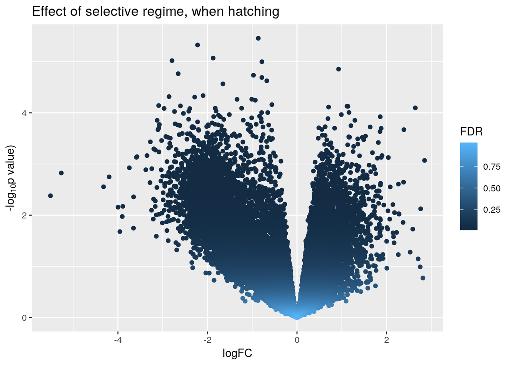

```r
z1 <- topTags(qlf3a, n=NumOfTags)$table
z1$logPValue <- -log10(z1$PValue)
ggplot(data=z1, mapping=aes(x=logFC, y=logPValue, color=FDR)) +
   geom_point() + theme_grey() + ylab(expression(paste("-log"[10], plain("p value)")))) +
   ggtitle('Effect of selective regime, when hatching')
```

According to model 3, contrast *a*, there are 2985 tags differentially expressed between selective regimes among samples allowed to hatch immediately, at FDR=0.05.

## Effect of selective regime when eggs are forced to undergo diapause

```r
qlf3b  <- glmQLFTest(fit3, contrast=c(0, 1, 0, -1))
topTags(qlf3b)
```

```
## Coefficient:  1*combinedRandDiap -1*combinedRegulDiap
##                  logFC      logCPM        F       PValue        FDR
## XLOC_027655  0.9214069  8.92865105 50.44389 1.515015e-05 0.02867084
## XLOC_008157 -2.2051529 -0.61107917 42.44951 3.414937e-05 0.02867084
## XLOC_020167 -3.7990218 -1.62296342 40.44066 4.270654e-05 0.02867084
## XLOC_028689 -2.1187828  0.57932526 40.05087 4.464602e-05 0.02867084
## XLOC_008190 -2.4035954  2.93890295 39.98808 4.496800e-05 0.02867084
## XLOC_033252 -2.8220194 -0.63710157 39.18981 4.930886e-05 0.02867084
## XLOC_026645 -0.6546516  6.58000182 38.37351 5.426551e-05 0.02867084
## XLOC_047029 -2.7230190 -0.01893114 36.37613 6.907619e-05 0.02867084
## XLOC_037384 -3.0460196 -0.56903814 35.10839 8.094748e-05 0.02867084
## XLOC_031654 -3.2234561 -1.56291053 35.00389 8.202877e-05 0.02867084
```

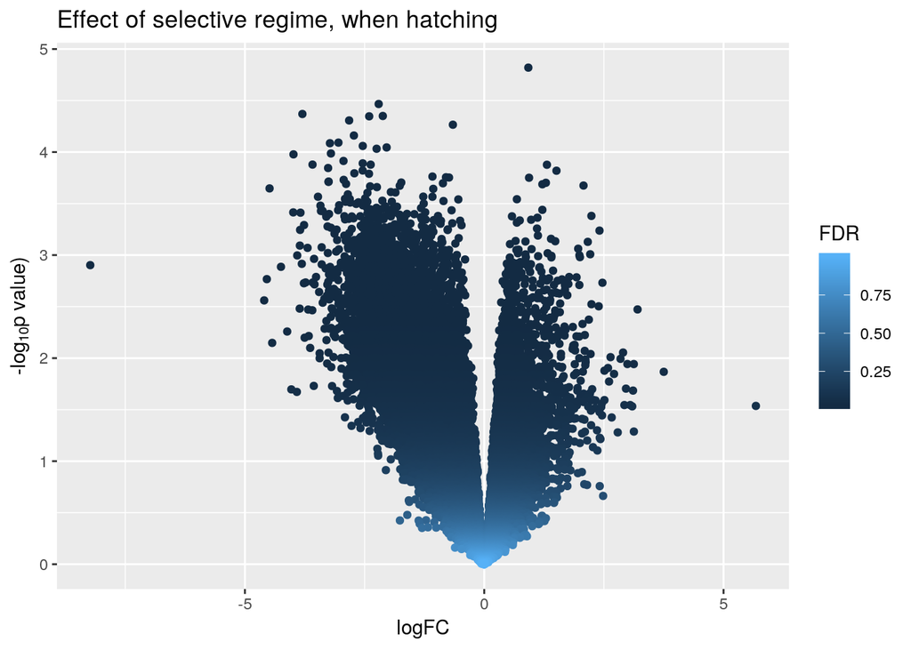

```r
z1 <- topTags(qlf3b, n=NumOfTags)$table
z1$logPValue <- -log10(z1$PValue)
ggplot(data=z1, mapping=aes(x=logFC, y=logPValue, color=FDR)) +
   geom_point() + theme_grey() + ylab(expression(paste("-log"[10], plain("p value)")))) +
   ggtitle('Effect of selective regime, when hatching')
```

According to model 3, contrast *b*, there are 5289 tags differentially expressed between selective regimes among samples undergoing diapause, at FDR=0.05. There is a reasonable correlation between the fold change in the two hatching conditions:

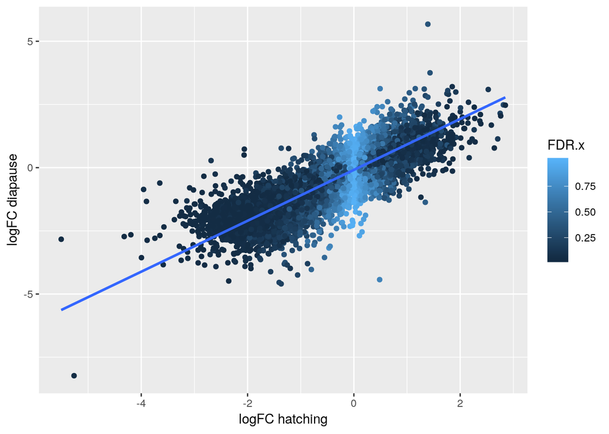

```r
z2 <- merge(topTags(qlf3a, n=NumOfTags)$table,
            topTags(qlf3b, n=NumOfTags)$table,
            by='row.names')
ggplot(data=z2, mapping=aes(x=logFC.x, y=logFC.y, color=FDR.x)) +
   geom_point() + geom_smooth(method='lm') + xlab('logFC hatching') + ylab('logFC diapause')
```

And this is the overlap between genes (or isoforms) affected by selective regime when hatching is immediate and those affected by selective regime when diapause is induced:

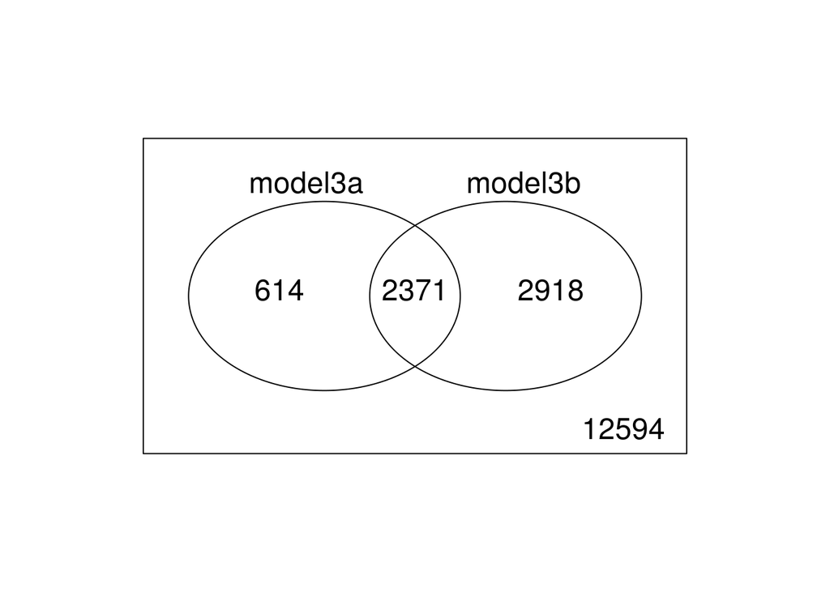

```r
significant <- cbind(model3a = topTags(qlf3a, n=NumOfTags, sort.by='none')$table$FDR <= 0.05,
                     model3b = topTags(qlf3b, n=NumOfTags, sort.by='none')$table$FDR <= 0.05)
vennDiagram(vennCounts(significant))
```

## Average effect of selective regime

```r
qlf3c  <- glmQLFTest(fit3, contrast=c(-0.5, 0.5, 0.5, -0.5))
topTags(qlf3c)
```

```
## Coefficient:  -0.5*combinedRegulHatch 0.5*combinedRandDiap 0.5*combinedRandHatch -0.5*combinedRegulDiap
##                  logFC    logCPM         F       PValue         FDR
## XLOC_027655  0.9251717 8.9286511 101.73353 4.448321e-07 0.003045998
## XLOC_026645 -0.7190405 6.5800018  92.59317 7.266991e-07 0.003045998
## XLOC_008190 -2.5284636 2.9389030  88.90822 8.967784e-07 0.003045998
## XLOC_023953 -0.6841386 6.6120397  85.55357 1.093508e-06 0.003045998
## XLOC_030600 -1.7708987 3.8365623  83.57182 1.233478e-06 0.003045998
## XLOC_024285 -2.1669490 2.5202203  69.60907 3.120830e-06 0.003045998
## XLOC_028689 -1.9034254 0.5793253  69.14219 3.228022e-06 0.003045998
## XLOC_032135 -0.8192658 7.5600175  69.05408 3.248731e-06 0.003045998
## XLOC_009961 -0.5743735 6.0837980  66.56415 3.903928e-06 0.003045998
## XLOC_032568 -1.4070349 7.3862114  65.93200 4.094202e-06 0.003045998
```

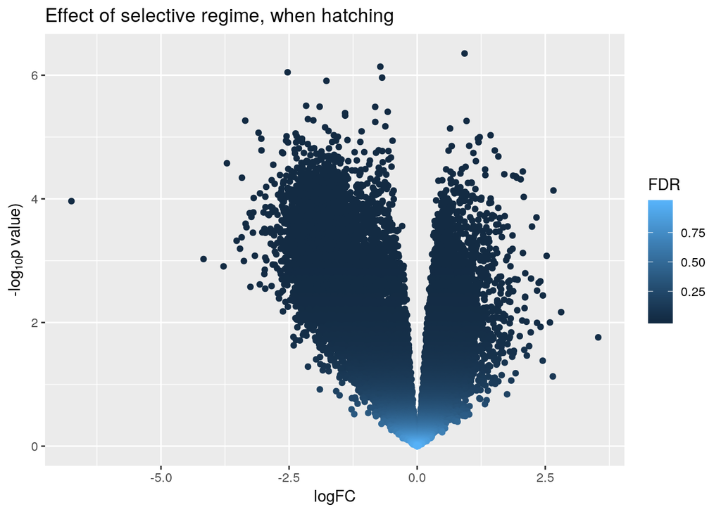

```r
z1 <- topTags(qlf3c, n=NumOfTags)$table
z1$logPValue <- -log10(z1$PValue)
ggplot(data=z1, mapping=aes(x=logFC, y=logPValue, color=FDR)) +
   geom_point() + theme_grey() + ylab(expression(paste("-log"[10], plain("p value)")))) +
   ggtitle('Effect of selective regime, when hatching')
```

# Model 4

```r
qlf4  <- glmQLFTest(fit4, coef=2)
topTags(qlf4)
```

```
## Coefficient:  regimerandom
##                 logFC     logCPM         F       PValue         FDR
## XLOC_020921 -2.018982  4.8276100 172.62705 3.683861e-07 0.006814037
## XLOC_043877 -3.193746  6.3759197 121.73876 1.621759e-06 0.014998836
## XLOC_037479 -2.154407  3.2163238  85.89128 6.901589e-06 0.042552895
## XLOC_000348  6.666243 -0.4217109  76.82522 1.087520e-05 0.050289658
## XLOC_027395  3.853572  0.3868021  60.48440 2.835411e-05 0.091696650
## XLOC_020688 -1.673719  4.2577578  56.63358 3.674319e-05 0.091696650
## XLOC_009724  2.876944  0.2635389  53.89944 4.459123e-05 0.091696650
## XLOC_016275  1.869734  3.6656431  53.11570 4.721010e-05 0.091696650
## XLOC_025173 -2.719464  1.9088392  52.94530 4.780421e-05 0.091696650
## XLOC_017180 -2.982087  2.0273862  51.55477 5.301047e-05 0.091696650
```

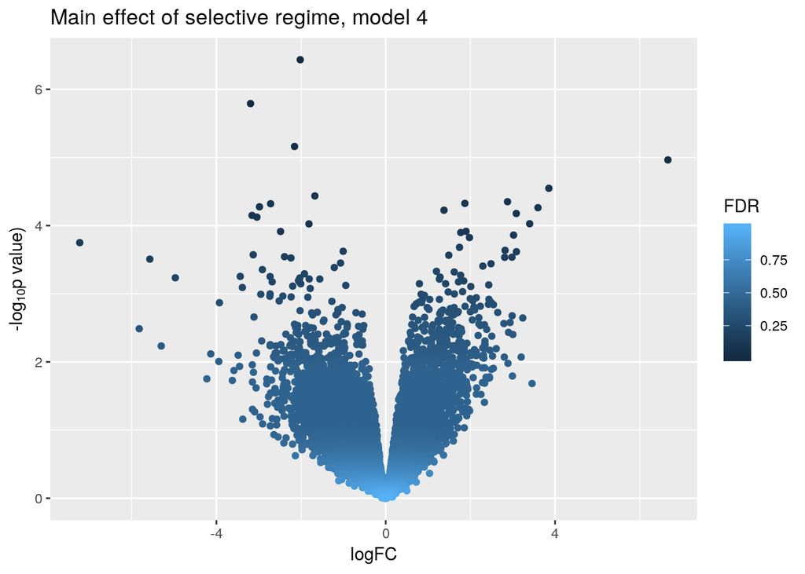

```r
z1 <- topTags(qlf4, n=NumOfTags)$table
z1$logPValue <- -log10(z1$PValue)
ggplot(data=z1, mapping=aes(x=logFC, y=logPValue, color=FDR)) +
   geom_point() + theme_grey() + ylab(expression(paste("-log"[10], plain("p value)")))) +
   ggtitle('Main effect of selective regime, model 4')
```

According to model 4, there are 65 tags significantly up- or downregulated by selective regime at FDR=0.25. I write the ordered list of genes with there fold change and p-values according to this model in a file, for later use in a functional enrichment analysis:

```r
write.table(topTags(qlf4, n=NumOfTags), file=sprintf("%s/regime.txt", args[2]), quote=FALSE)
```

# Model 5

```r
qlf5  <- glmQLFTest(fit5, coef=2)
topTags(qlf5)
```

```
## Coefficient:  regimerandom
##                  logFC   logCPM        F       PValue        FDR
## XLOC_023953 -0.8646776 6.612040 68.06870 3.491297e-06 0.03709955
## XLOC_030600 -2.2209199 3.836562 64.08018 4.717492e-06 0.03709955
## XLOC_032568 -1.8724888 7.386211 56.84773 8.504965e-06 0.03709955
## XLOC_024285 -2.7914942 2.520220 55.51519 9.546008e-06 0.03709955
## XLOC_026645 -0.7834294 6.580002 54.95422 1.002853e-05 0.03709955
## XLOC_027655  0.9289364 8.928651 51.29145 1.398795e-05 0.04188624
## XLOC_008190 -2.6533318 2.938903 49.13599 1.717377e-05 0.04188624
## XLOC_032135 -0.9722472 7.560018 48.42231 1.841126e-05 0.04188624
## XLOC_002615 -0.7847700 9.044465 47.39542 2.038040e-05 0.04188624
## XLOC_009961 -0.6746834 6.083798 45.92764 2.364122e-05 0.04305634
```

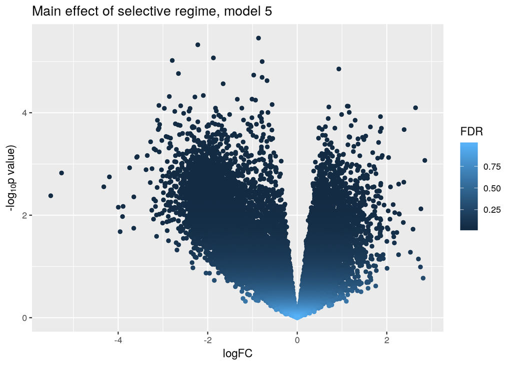

```r
z1 <- topTags(qlf5, n=NumOfTags)$table
z1$logPValue <- -log10(z1$PValue)
ggplot(data=z1, mapping=aes(x=logFC, y=logPValue, color=FDR)) +
   geom_point() + theme_grey() + ylab(expression(paste("-log"[10], plain("p value)")))) +
   ggtitle('Main effect of selective regime, model 5')
```

# Model 6

```r
qlf6  <- glmQLFTest(fit6, coef=2)
topTags(qlf6)
```

```
## Coefficient:  regimerandom
##                 logFC     logCPM         F       PValue       FDR
## XLOC_020921 -1.995609  4.8275332 113.03065 7.124887e-06 0.1317890
## XLOC_043877 -3.141690  6.3758644  81.29444 2.328552e-05 0.2153561
## XLOC_037479 -2.148076  3.2157895  55.65069 8.753821e-05 0.4556249
## XLOC_000348  6.749065 -0.4156904  53.29841 1.014816e-04 0.4556249
## XLOC_025173 -2.951951  1.9092244  50.35058 1.231618e-04 0.4556249
## XLOC_043872 -7.580934 -1.2813197  54.66435 1.857266e-04 0.4929989
## XLOC_024723  3.435747  2.0024823  44.04678 1.931546e-04 0.4929989
## XLOC_020688 -1.740333  4.2576198  39.84500 2.692514e-04 0.4929989
## XLOC_027395  3.615407  0.3904945  39.65618 2.734908e-04 0.4929989
## XLOC_021141  3.753503 -0.3644969  39.22427 2.835091e-04 0.4929989
```

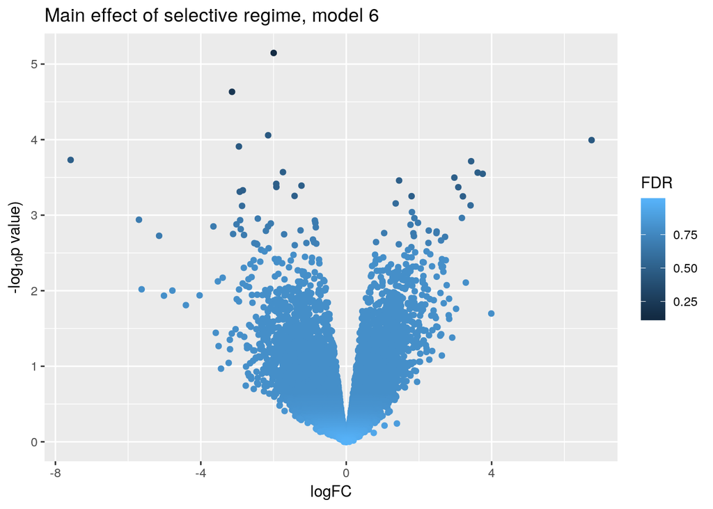

```r
z1 <- topTags(qlf6, n=NumOfTags)$table
z1$logPValue <- -log10(z1$PValue)
ggplot(data=z1, mapping=aes(x=logFC, y=logPValue, color=FDR)) +
   geom_point() + theme_grey() + ylab(expression(paste("-log"[10], plain("p value)")))) +
   ggtitle('Main effect of selective regime, model 6')
```

According to model 6, there are 2 tags significantly up- or downregulated by selective regime at FDR=0.25. And this is how the different models agree on what genes are differentially expressed in different selective regimes:

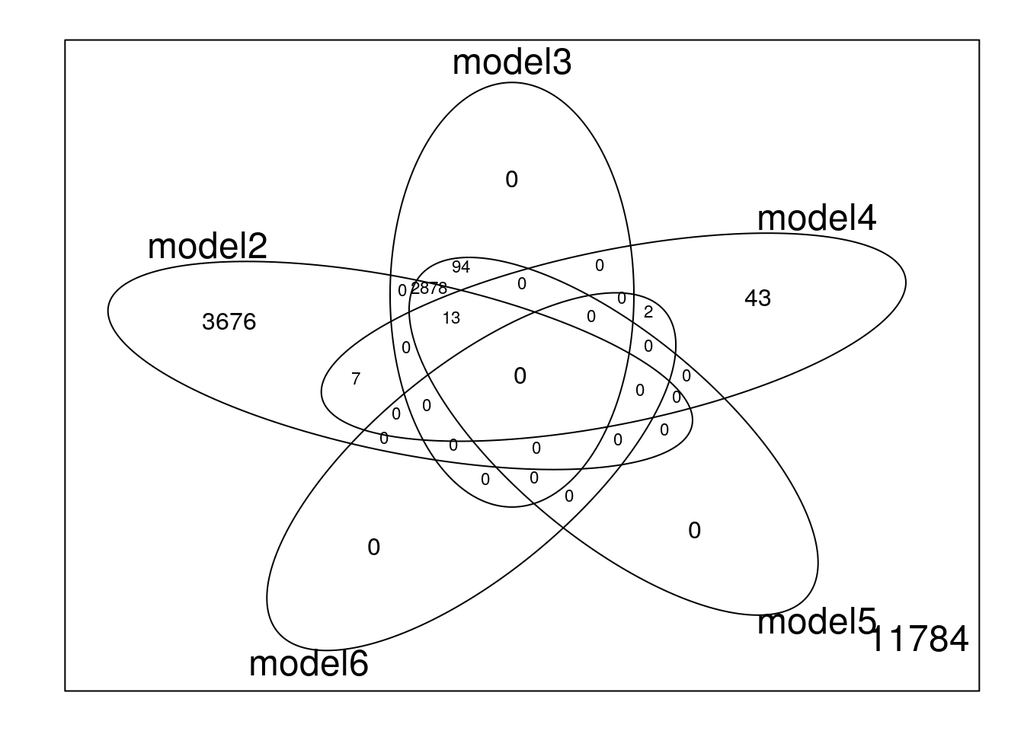

```r
significant <- cbind(model2 = topTags(qlf2,  n=NumOfTags, sort.by='none')$table$FDR <= 0.01,
                     model3 = topTags(qlf3a, n=NumOfTags, sort.by='none')$table$FDR <= 0.05,
                     model4 = topTags(qlf4,  n=NumOfTags, sort.by='none')$table$FDR <= 0.25,
                     model5 = topTags(qlf5,  n=NumOfTags, sort.by='none')$table$FDR <= 0.05,
                     model6 = topTags(qlf6,  n=NumOfTags, sort.by='none')$table$FDR <= 0.25)
vennDiagram(vennCounts(significant))
```

Note that I am using a different FDR for each model, to obtain more or less comparable and positive numbers.